# Управляющие конструкции for, if, while и матрицы: задания

### Задание №1

Даны 2 числа a и b. Нужно вывести на экран значение числа, которое больше.

### Задание №2

Дано число. Нужно узнать отрицательное оно или нет.

### Задание №3

Условие задачи 2, но теперь нужно определять, равно ли число нулю. То есть, если число равно 0, то выводить “Число равно 0!”.

### Задание №4

Даны 3 числа: a,b и c. Нужно вывести на экран значение числа, которое больше.

### Задание №5

Дано число a. Вывести на экран четное оно или нет.

### Задание №6

Дан массив, состоящий из рандомных чисел. Длина массива равна 15. Вывести на экран с 5 по 12 элементы массива.

### Задание №7

Дан массив, состоящий из рандомных чисел произвольной длины. Вывести на экран все элементы массива. Сделать код оптимальным в том смысле, что если длина массива поменяется вам не нужно будет переписывать код.

### Задание №8

Имеется 2 числа: вывести все целые числа, которые находятся между ними.

### Задание №9

Дан массив. Найти сумму всех элементов этого массива.

### Задание №10

Дан массив. Найти произведение всех элементов этого массива.

### Задание №11

Найти факториал числа $n$ ($n!$). Помним, что $0! = 1$

### Задание №12

Дано число k. Нужно вывести треугольник с изчезающим первым значением. Например, `k = 9`, тогда вывод должен быть следующим.

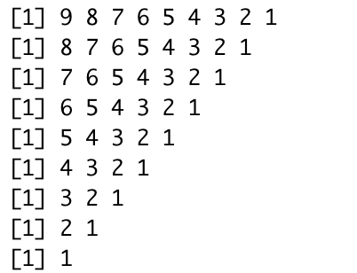

### Задание №13

Для настольной игры используются карточки с номерами от 1 до N. Одна карточка потерялась. Найдите ее, зная номера оставшихся карточек.

### Задание №14

Задан массив и числа a, b. Вывести все индексы переменных, где выполняется $a < x[i] < b$.

### Задание №15

Дан массив. Посчитать сумму всех четных элементов массива.

### Задание №16

Есть переменная action. Она может быть равна либо “Сложить”, либо “Перемножить”. В зависимости от этой переменной нужно сложить или перемножить все элементы массива.

### Задание №17

По данному натуральном n вычислите сумму $1!+2!+3!+...+n!$. В решении этой задачи можно использовать только один цикл.

### Задание №18

Есть матрица состоящая из нулей. Нужно заполнить её таким образом, чтобы значение элемента, который находится в i-ой строчке и j-ом столбце, равно i + j.

### Задание №19

Даны числа a и b (a < b). Нужно увеличивать число a на единицу и уменьшать число b на единицу пока число a меньше числа b.

### Задание №20

Дан массив длины n, состоящий из одних 0. Вы выбираете рандомное число от 1 до n (с помощью функции sample). Это рандомное число показывает индекс элемента массива, который нужно изменить с 0 на 1. После чего вы опять выбираете рандомное число. Это делается до тех пор пока массив не будет состоять из одних 1. Например: был массив с(0,0,0,0). Выпало рандомное число 3. Теперь массив выглядит так : c(0,0,1,0). Вы продолжаете так делать, пока все нули не исчезнут. Нужно посчитать, сколько раз выбиралось рандомное число.

### Задание №21 (!!)

Нужно подкинуть монетку 10 раз. Сколько раз выпала “Решка” и “Орел” в общем числе подкидываний? Теперь подкиньте монетку 100/1000/10000 раз. Какую закономерность вы видите?

*Подсказка:* Для того чтобы подкинуть монетку, можно использовать функцию `sample`, которая из двух значений (0 и 1, где 0 – “Решка”, а 1 – “Орел”) случайным образом выдает одно. И так `n` раз.